# IODS course project

Iris Orizar

# Introduction to Open Data Science - Course Project

# About the project

This is the **Open Data Science** course. I am particularly interested in learning how to use **GitHUB** and get familiarize with **R Markdown**. Hopefully, the learning curve will not be too steep for me to follow.

```r
# This is a so-called "R chunk" where you can write R code.

date()
```

```
## [1] "Thu Dec 03 22:06:33 2020"
```

# Regression Analysis and Model Validation

## A. Data wrangling

Data wrangling is an important step in data analysis. This includes gathering, inspecting, transforming and mapping the data into a appropriate format for a variety of data analyses.

### a.1 Demo data sets

First step is to laod the data to the console. The data set that will be using for can be accessed using this link ‘http://www.helsinki.fi/~kvehkala/JYTmooc/JYTOPKYS3-data.txt’. Information about the data set can be acessed through this link: ‘https://www.mv.helsinki.fi/home/kvehkala/JYTmooc/JYTOPKYS3-meta.txt’.

After loading the data we can check the dimension and structure of the data using **dim()** and **str()**, respectively.

```r
date()
```

```
## [1] "Thu Dec 03 22:06:33 2020"
```

```r
# installing packages

#install.packages(c('dplyr', 'ggplot2'))
library(dplyr)
library(GGally)
library(ggplot2)

# Read the data
data <- read.table("http://www.helsinki.fi/~kvehkala/JYTmooc/JYTOPKYS3-data.txt", sep = "\t", header = TRUE)

# Inspect the dimension and structure of the data
dim(data)
```

```
## [1] 183  60
```

```r
str(data)
```

```
## 'data.frame':    183 obs. of  60 variables:
##  $ Aa      : int  3 2 4 4 3 4 4 3 2 3 ...
##  $ Ab      : int  1 2 1 2 2 2 1 1 1 2 ...
##  $ Ac      : int  2 2 1 3 2 1 2 2 2 1 ...
##  $ Ad      : int  1 2 1 2 1 1 2 1 1 1 ...
##  $ Ae      : int  1 1 1 1 2 1 1 1 1 1 ...
##  $ Af      : int  1 1 1 1 1 1 1 1 1 2 ...
##  $ ST01    : int  4 4 3 3 4 4 5 4 4 4 ...
##  $ SU02    : int  2 2 1 3 2 3 2 2 1 2 ...
##  $ D03     : int  4 4 4 4 5 5 4 4 5 4 ...
##  $ ST04    : int  4 4 4 4 3 4 2 5 5 4 ...
##  $ SU05    : int  2 4 2 3 4 3 2 4 2 4 ...
##  $ D06     : int  4 2 3 4 4 5 3 3 4 4 ...
##  $ D07     : int  4 3 4 4 4 5 4 4 5 4 ...
##  $ SU08    : int  3 4 1 2 3 4 4 2 4 2 ...
```

[output cut: 46 more lines]

### a.2 Adding new columns

It is also possible to add new columns in the data set. In this exercise, we are going to create new column **attitude**, by scaling the column **data$attitude** by 10.

we are also adding new column (**attitude**, **deep**, **stra**, **surf**) corresponding to the mean value for questions related to deep, strategic and surface learning.

```r
#-- create 'attitude' column
data$attitude<-data$Attitude/10

#-- create 'deep' column for questions related to deep learning
deep_q<-c("D03", "D11", "D19", "D27", "D07", "D14",
          "D22", "D30","D06",  "D15", "D23", "D31")
deep_c<-select(data, one_of(deep_q))
data$deep<-rowMeans(deep_c)

#-- create 'stra' column for questions related to strategic learning
strategic_q <- c("ST01","ST09","ST17","ST25","ST04","ST12",
                         "ST20","ST28")

strategic_c<-select(data, one_of(strategic_q))
data$stra<-rowMeans(strategic_c)

#create 'surf' column for questions related to surface learning
surface_q <- c("SU02","SU10","SU18","SU26", "SU05","SU13",
                       "SU21","SU29","SU08","SU16","SU24","SU32")
surface_c<-select(data, one_of(surface_q))
data$surf<-rowMeans(surface_c)
```

### a.2 Subsetting data set

We can create a subset from the original data using **dplyr** package. We are going to creat a data set that only contains a subset of the originial data set and we are calling it **l2014**.

```r
library(dplyr)

#-- columns to keep
keep_columns <- c("gender","Age","attitude", "deep",
                  "stra", "surf", "Points")

#-- create a new dataset
l2014<-select(data, one_of(keep_columns))

#-- check structure
str(l2014)
```

```
## 'data.frame':    183 obs. of  7 variables:
##  $ gender  : chr  "F" "M" "F" "M" ...
##  $ Age     : int  53 55 49 53 49 38 50 37 37 42 ...
##  $ attitude: num  3.7 3.1 2.5 3.5 3.7 3.8 3.5 2.9 3.8 2.1 ...
##  $ deep    : num  3.58 2.92 3.5 3.5 3.67 ...
##  $ stra    : num  3.38 2.75 3.62 3.12 3.62 ...
##  $ surf    : num  2.58 3.17 2.25 2.25 2.83 ...
##  $ Points  : int  25 12 24 10 22 21 21 31 24 26 ...
```

### a.3 Data visualization

We are using **GGally** and **ggplot2** packages in creating a graphical overview of the data set we just created.

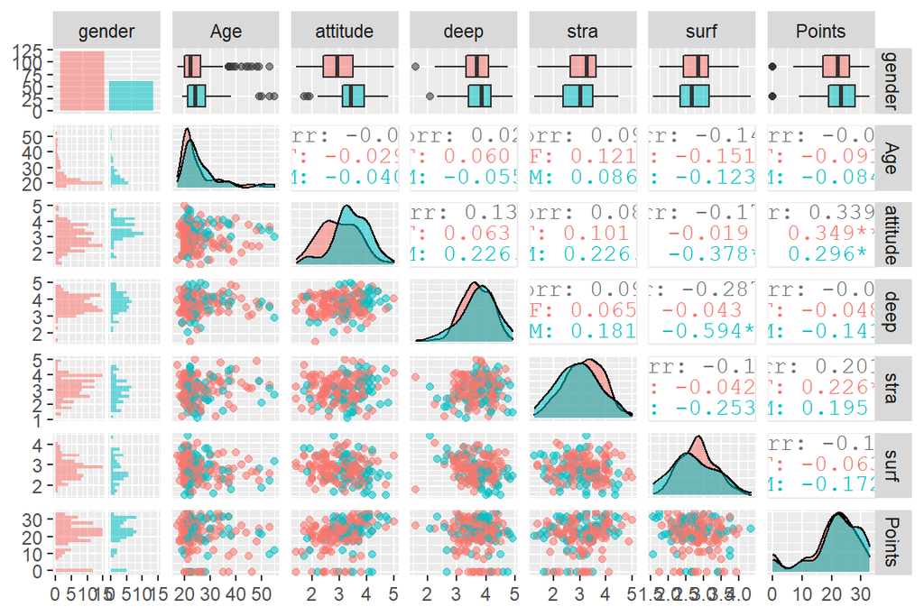

```r
library(GGally)
library(ggplot2)

#creating plot matrix using ggpairs

p <- ggpairs(l2014, mapping = aes(col = gender, alpha = 0.3),
             lower = list(combo = wrap("facethist", bins = 20)))

p
```

The graphical output is a scatter plot matrix among the parameters with colors corresponding to **gender**. There is gender biased in the data set, however the distribution is generally normal for both gender in all student’s attitude towards statistics and approaches to learning. In addition, age distribution is skewed towards younger participants between ages 20 - 30.

## B. Multiple Linear Regression

Linear regression is a statistical approach that demonstrates relationships between a dependent variable **y** and one or more explanatory variables **X**.

In this exercise, we are selecting three explanatory variables (attitude, stra, surf) from l2014 data set we created from the previous section to explain the exam points of the students.

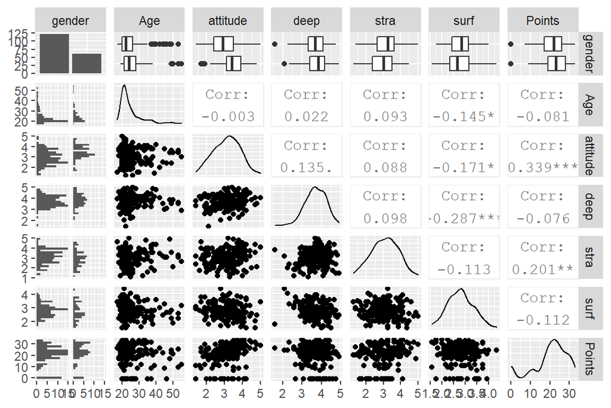

```r
#-- visualize the relationships
library(GGally)
library(ggplot2)

ggpairs(l2014, lower = list(combo = wrap("facethist", bins = 20)))
```

```r
#-- create a regression model with multiple explanatory variables
# lm <- the type of model we are using (linear model)
# points <- dependent variable
# attitude + stra + surf <- explanatory variables

m1 <- lm(Points~attitude + stra + surf, data = l2014)

#-- print out summary
summary(m1)
```

```
##
## Call:
## lm(formula = Points ~ attitude + stra + surf, data = l2014)
##
## Residuals:
##     Min      1Q  Median      3Q     Max
## -25.151  -3.212   2.233   5.257  13.694
##
## Coefficients:
##             Estimate Std. Error t value Pr(>|t|)
## (Intercept)   4.7781     5.1577   0.926   0.3555
## attitude      3.7570     0.8308   4.522 1.11e-05 ***
## stra          1.8968     0.7832   2.422   0.0164 *
## surf         -0.6262     1.1494  -0.545   0.5866
## ---
## Signif. codes:  0 '***' 0.001 '**' 0.01 '*' 0.05 '.' 0.1 ' ' 1
##
## Residual standard error: 8.082 on 179 degrees of freedom
## Multiple R-squared:  0.146,  Adjusted R-squared:  0.1317
## F-statistic:  10.2 on 3 and 179 DF,  p-value: 3.089e-06
```

Summary of the results from the first model (**m1**) shows that student’s **attitude** have significant statistical effect to their total exam points.

We can make another model, this time only including **attitude** as the explanatory variable of exam points.

```r
#-- model 2 with only 1 explanatory variabe
m2<-lm(Points~attitude, data = l2014)

#-- printing summary
summary(m2)
```

```
##
## Call:
## lm(formula = Points ~ attitude, data = l2014)
##
## Residuals:
##     Min      1Q  Median      3Q     Max
## -24.934  -2.716   1.883   5.180  13.289
##
## Coefficients:
##             Estimate Std. Error t value Pr(>|t|)
## (Intercept)   8.0926     2.6494   3.054   0.0026 **
## attitude      4.0099     0.8266   4.851 2.63e-06 ***
## ---
## Signif. codes:  0 '***' 0.001 '**' 0.01 '*' 0.05 '.' 0.1 ' ' 1
##
## Residual standard error: 8.182 on 181 degrees of freedom
## Multiple R-squared:  0.1151, Adjusted R-squared:  0.1102
## F-statistic: 23.54 on 1 and 181 DF,  p-value: 2.635e-06
```

However, model needs to be evaluated and check if it violates assumptions for linear regression.

## b.2 Model validation

Linear regression has several assumptions:  
+ errors are normally distributed  
+ errors are not correlated  
+ errors have constant variance  
+ the size of a given error does not depend on the explanatory variable

This assumptions can be visually inspected using **plot()** command.

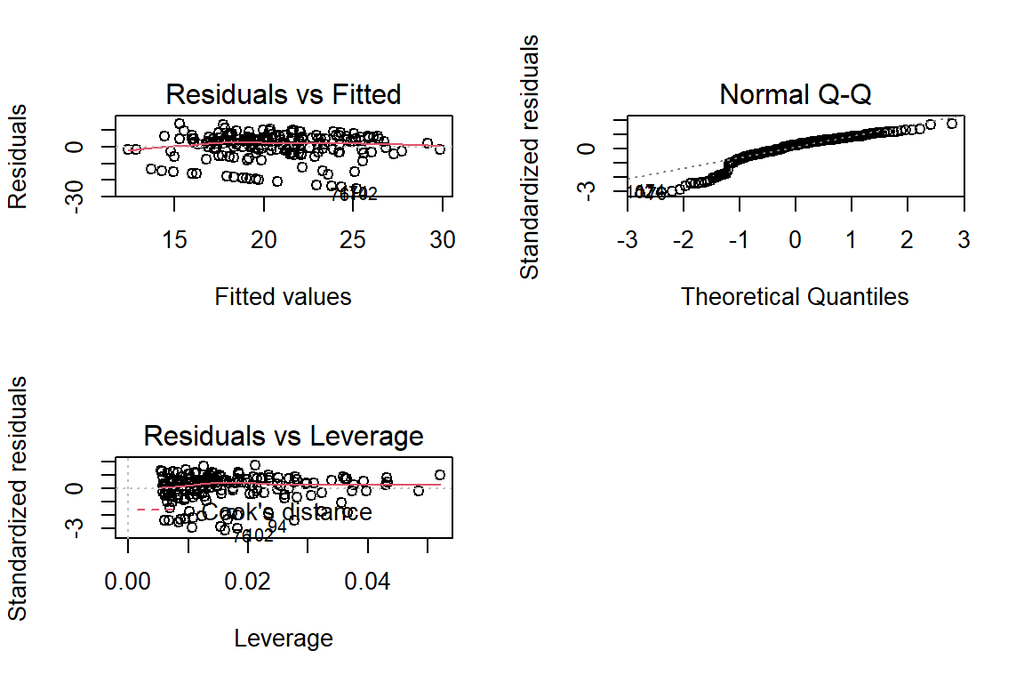

```r
# create a regression model with multiple explanatory variables
l2014<-as.data.frame(l2014)
m3=lm(Points ~ attitude + stra, data = l2014)
# draw diagnostic plots using the plot() function. Choose the plots 1, 2 and 5
par(mfrow = c(2,2))
plot(m3, which = c(1, 2, 5))
```

# Logistic Regression

## Data exploration

In this data analysis we are going to use a data set from [UCI Machine Learning Repository] (https://archive.ics.uci.edu/ml/datasets/Student+Performance#). This data set was originally aimed to predict student performance on Math and Portuguese Language subjects in secondary education (high school). This also includes information about alcohol consumption.

For this exercise, we are going to explore relationship between alcohol consumption and other parameters available. There are two separate data sets from this website, but we are going to use the combined data set. This joined data set can be access throuhg this link: http://s3.amazonaws.com/assets.datacamp.com/production/course_2218/datasets/alc.txt

```r
library(dplyr)

url <- "http://s3.amazonaws.com/assets.datacamp.com/production/course_2218/datasets/alc.txt"

# read the data

data<-read.table(url, sep = ",", header = TRUE)
```

```r
str(data)
dim(data)
glimpse(data)
colnames(data)
```

[output not shown]

The data set contains 382 observations and 35 covariates. Two new columns were added to the original data set (**$alc_use** and **$high_use**). **alc_use** is the average alcohol consumption during workday (**$Dalc**) and weekend (**$Walc**). **high_use** is a logical column which contains boolean data type (TRUE or FALSE).

## Graphical exploration

On this exercise, we are going to explore relationship of alcohol consumption (**high_use**) to **failures**, **absences**, **freetime**. **sex**.

**failures** = number of past class failures  
**Hypothesis**: Failing a subject could motivate the student to drink more, and the more subject they fail, the more alcohol they consumes.  
Alternatively, **failures** is also a proxy for success. The less failed subjects they had, the more subjects they did not fail. This might also caused alcohol consumption.

**Note**: The exploration also look at the possible effect of sex to alcohol consumption due to failing subjects.

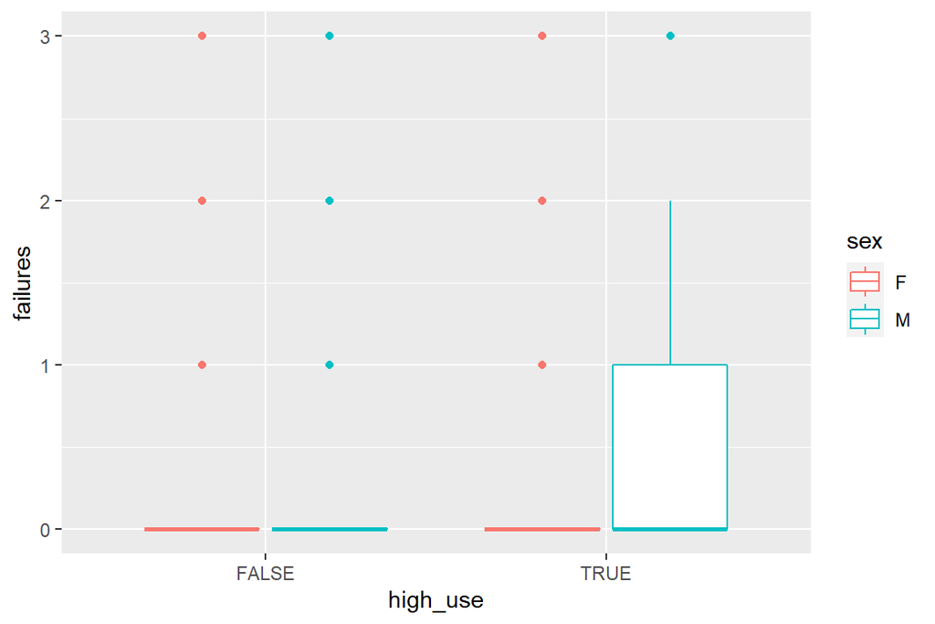

```r
library(ggplot2)
library(dplyr)

g1 <- ggplot(data, aes(x = high_use, y = failures, col = sex))

# define the plot as a boxplot and draw it
g1 + geom_boxplot() + ylab("failures")
```

```r
data %>% group_by(failures, sex, high_use) %>% summarise(count = n())
```

```
## # A tibble: 16 x 4
## # Groups:   failures, sex [8]
##    failures sex   high_use count
##       <int> <chr> <lgl>    <int>
##  1        0 F     FALSE      136
##  2        0 F     TRUE        32
##  3        0 M     FALSE       98
##  4        0 M     TRUE        50
##  5        1 F     FALSE       14
##  6        1 F     TRUE         2
##  7        1 M     FALSE        8
##  8        1 M     TRUE        14
##  9        2 F     FALSE        3
## 10        2 F     TRUE         5
## 11        2 M     FALSE        2
## 12        2 M     TRUE         1
## 13        3 F     FALSE        4
## 14        3 F     TRUE         2
## 15        3 M     FALSE        5
## 16        3 M     TRUE         6
```

Next,  
**absences** = number of school absences  
**Hypothesis** = The number of absences might indicate more alcohol consumption.

**NOTE**: The exploration also includes the effect of sex in the relationship of high alcohol consumption and number of absences.

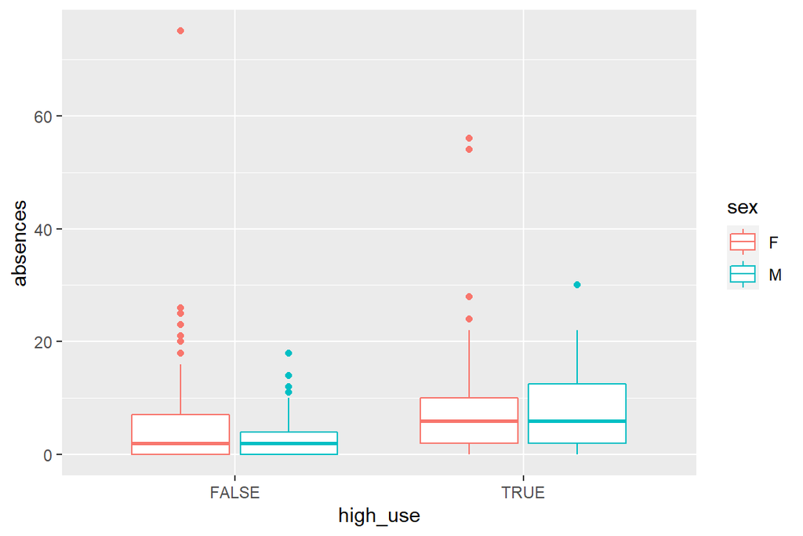

```r
g2 <- ggplot(data, aes(x = high_use, y = absences, col = sex))

# define the plot as a boxplot and draw it
g2 + geom_boxplot() + ylab("absences")
```

The resulting graph shows students with more absences have higher alcohol consumption, however difference between sexes is not apparent.

```r
data %>% group_by(absences, sex, high_use) %>% summarise(count = n())
```

```
## # A tibble: 74 x 4
## # Groups:   absences, sex [50]
##    absences sex   high_use count
##       <int> <chr> <lgl>    <int>
##  1        0 F     FALSE       55
##  2        0 F     TRUE         7
##  3        0 M     FALSE       39
##  4        0 M     TRUE        15
##  5        1 F     FALSE        1
##  6        1 F     TRUE         1
##  7        1 M     FALSE        1
##  8        2 F     FALSE       24
##  9        2 F     TRUE         8
## 10        2 M     FALSE       30
## # ... with 64 more rows
```

Finally, **freetime** = free time after school. **Hypothesis**: The more free time the students have the more alcohol they consumes.

*NOTE**: The effect of sex to the relationship of alcohol consumption and free time is also explored.

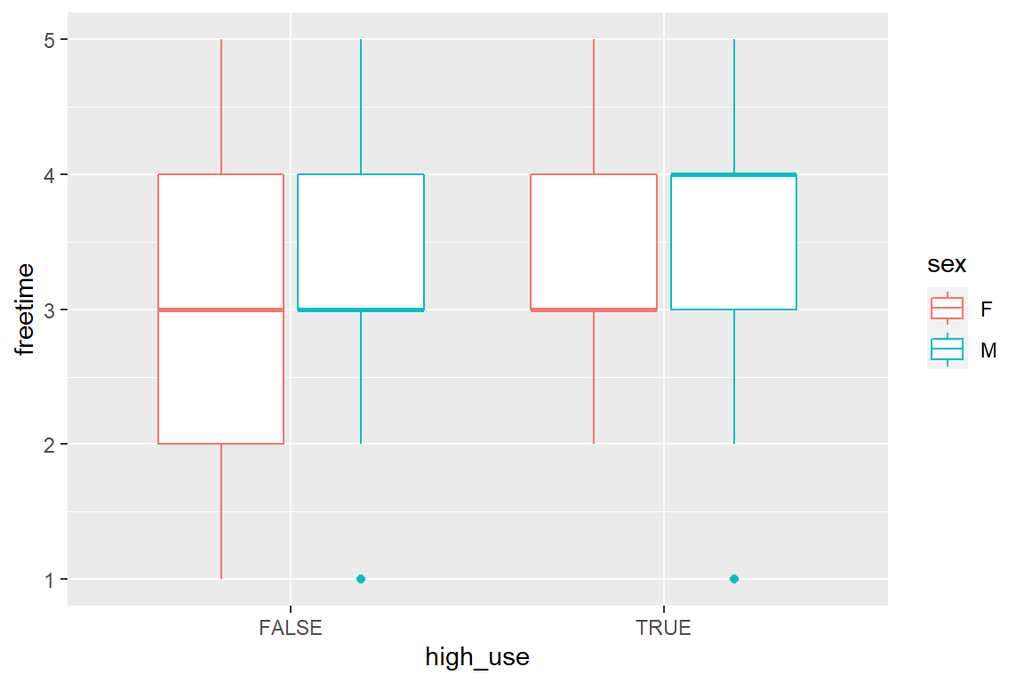

```r
g3 <- ggplot(data, aes(x = high_use, y = freetime, col = sex))

# define the plot as a boxplot and draw it
g3 + geom_boxplot() + ylab("freetime")
```

```r
data %>% group_by(freetime, sex, high_use) %>% summarise(count = n())
```

```
## # A tibble: 19 x 4
## # Groups:   freetime, sex [10]
##    freetime sex   high_use count
##       <int> <chr> <lgl>    <int>
##  1        1 F     FALSE       14
##  2        1 M     FALSE        2
##  3        1 M     TRUE         2
##  4        2 F     FALSE       30
##  5        2 F     TRUE         5
##  6        2 M     FALSE       17
##  7        2 M     TRUE        10
##  8        3 F     FALSE       72
##  9        3 F     TRUE        19
## 10        3 M     FALSE       44
## 11        3 M     TRUE        21
## 12        4 F     FALSE       35
## 13        4 F     TRUE        15
## 14        4 M     FALSE       34
## 15        4 M     TRUE        25
## 16        5 F     FALSE        6
## 17        5 F     TRUE         2
## 18        5 M     FALSE       16
## 19        5 M     TRUE        13
```

Overall, we can further explore the relationship of **failures**, **absences**, **freetime** and **sex** by fitting a model.

## Fitting a model

For this exercise, we are going to use **glm()** function to fit a model to test relationship between high alcohol consumption and **failures**, **absences**, **freetime** and **sex**. The first model also includes interaction of sex with the first three explanatory variable.

```r
## fitting model using glm()
m1 <- glm(high_use ~ failures*sex + absences*sex + freetime*sex,
          data = data, family = "binomial")

#-- print out a summary of the model
summary(m1)
```

```
##
## Call:
## glm(formula = high_use ~ failures * sex + absences * sex + freetime *
##     sex, family = "binomial", data = data)
##
## Deviance Residuals:
##     Min       1Q   Median       3Q      Max
## -1.8748  -0.7712  -0.5805   0.8336   2.0780
##
## Coefficients:
##               Estimate Std. Error z value Pr(>|z|)
## (Intercept)   -3.65893    0.75978  -4.816 1.47e-06 ***
## failures       0.50014    0.23309   2.146  0.03190 *
## sexM           2.00416    0.99171   2.021  0.04329 *
## absences       0.04276    0.01717   2.490  0.01277 *
## freetime       0.59747    0.21222   2.815  0.00487 **
## failures:sexM -0.07163    0.31644  -0.226  0.82091
## sexM:absences  0.12078    0.03932   3.072  0.00213 **
## sexM:freetime -0.52767    0.27406  -1.925  0.05418 .
## ---
## Signif. codes:  0 '***' 0.001 '**' 0.01 '*' 0.05 '.' 0.1 ' ' 1
##
## (Dispersion parameter for binomial family taken to be 1)
##
##     Null deviance: 462.21  on 381  degrees of freedom
## Residual deviance: 398.66  on 374  degrees of freedom
## AIC: 414.66
##
## Number of Fisher Scoring iterations: 4
```

Based on this model, there is no significant linear relationship between **failure-sex** and high alcohol consumption. Furthermore, **freetime-sex** has very low significant effect to high alcohol consumption.  
Lets do some model selection using **drop1**.

```r
#-- Model selection
drop1(m1)
```

```
## Single term deletions
##
## Model:
## high_use ~ failures * sex + absences * sex + freetime * sex
##              Df Deviance    AIC
## <none>            398.66 414.66
## failures:sex  1   398.71 412.71
## sex:absences  1   409.06 423.06
## sex:freetime  1   402.47 416.47
```

Based on **AIC** values, we can drop **failures-sex** to improve the predictive capacity of the model.

Let us run the new model (**m2**)which does not have **failures-sex** as an explanatory variable.

```r
#-- print out the coefficients of the model
m2<- glm(high_use ~ failures + absences*sex + freetime*sex,
         data = data, family = "binomial")
summary(m2)
```

```
##
## Call:
## glm(formula = high_use ~ failures + absences * sex + freetime *
##     sex, family = "binomial", data = data)
##
## Deviance Residuals:
##     Min       1Q   Median       3Q      Max
## -1.8722  -0.7682  -0.5845   0.8355   2.0697
##
## Coefficients:
##               Estimate Std. Error z value Pr(>|z|)
## (Intercept)   -3.62942    0.74603  -4.865 1.14e-06 ***
## failures       0.46128    0.15826   2.915  0.00356 **
## absences       0.04272    0.01717   2.488  0.01284 *
## sexM           1.98088    0.98484   2.011  0.04429 *
## freetime       0.59264    0.21064   2.814  0.00490 **
## absences:sexM  0.12148    0.03930   3.091  0.00199 **
## sexM:freetime -0.52886    0.27376  -1.932  0.05338 .
## ---
## Signif. codes:  0 '***' 0.001 '**' 0.01 '*' 0.05 '.' 0.1 ' ' 1
##
## (Dispersion parameter for binomial family taken to be 1)
##
##     Null deviance: 462.21  on 381  degrees of freedom
## Residual deviance: 398.71  on 375  degrees of freedom
## AIC: 412.71
##
## Number of Fisher Scoring iterations: 4
```

```r
#-- model selection
drop1(m2)
```

```
## Single term deletions
##
## Model:
## high_use ~ failures + absences * sex + freetime * sex
##              Df Deviance    AIC
## <none>            398.71 412.71
## failures      1   407.00 419.00
## absences:sex  1   409.21 421.21
## sex:freetime  1   402.54 414.54
```

Model **m2** have lower AIC value after **drop1()**. This is still the best model so far, with almost all explanatory variable having significant linear correlation with high alcohol consumption.

Let us stuck with this model and further explore the results.

```r
# compute odds ratios (OR)
OR <- coef(m2) %>% exp

# compute confidence intervals (CI)
CI <- confint(m2) %>% exp
# print out the odds ratios with their confidence intervals
cbind(OR, CI)
```

```
##                       OR       2.5 %     97.5 %
## (Intercept)   0.02653166 0.005624733  0.1059779
## failures      1.58609902 1.161286045  2.1693083
## absences      1.04364576 1.008744304  1.0820700
## sexM          7.24908868 1.080292144 52.1118881
## freetime      1.80875631 1.211856934  2.7780692
## absences:sexM 1.12917143 1.048102129  1.2237126
## sexM:freetime 0.58927770 0.341091518  1.0006724
```

We can test the predictive capacity of the model using the results from model **m2**.

```r
# print out the coefficients of the model
m2<- glm(high_use ~ failures + absences*sex + freetime*sex,
         data = data, family = "binomial")

# predict() the probability of high_use
probabilities <- predict(m2, type = "response")

# add the predicted probabilities to 'alc'
data <- mutate(data, probability = probabilities)

# use the probabilities to make a prediction of high_use
data <- mutate(data, prediction = probabilities > 0.5)

# see the last ten original classes, predicted probabilities, and class predictions
select(data, failures, absences, sex, high_use, probability, prediction) %>% tail(10)
```

```
##     failures absences sex high_use probability prediction
## 373        1        0   M    FALSE  0.26974475      FALSE
## 374        1       14   M     TRUE  0.79685020       TRUE
## 375        0        2   F    FALSE  0.14603326      FALSE
## 376        0        7   F    FALSE  0.27691468      FALSE
## 377        1        0   F    FALSE  0.31054319      FALSE
## 378        0        0   F    FALSE  0.13569710      FALSE
## 379        1        0   F    FALSE  0.07073197      FALSE
## 380        1        0   F    FALSE  0.07073197      FALSE
## 381        0        3   M     TRUE  0.28888590      FALSE
## 382        0        0   M     TRUE  0.19886333      FALSE
```

```r
# tabulate the target variable versus the predictions
table(high_use = data$high_use, prediction = data$prediction)
```

```
##         prediction
## high_use FALSE TRUE
##    FALSE   251   19
##    TRUE     78   34
```

```r
table(data$high_use)
```

```
##
## FALSE  TRUE
##   270   112
```

The model is good in predicting low alcohol consumption than high alcohol consumption. The model still needs improvement.

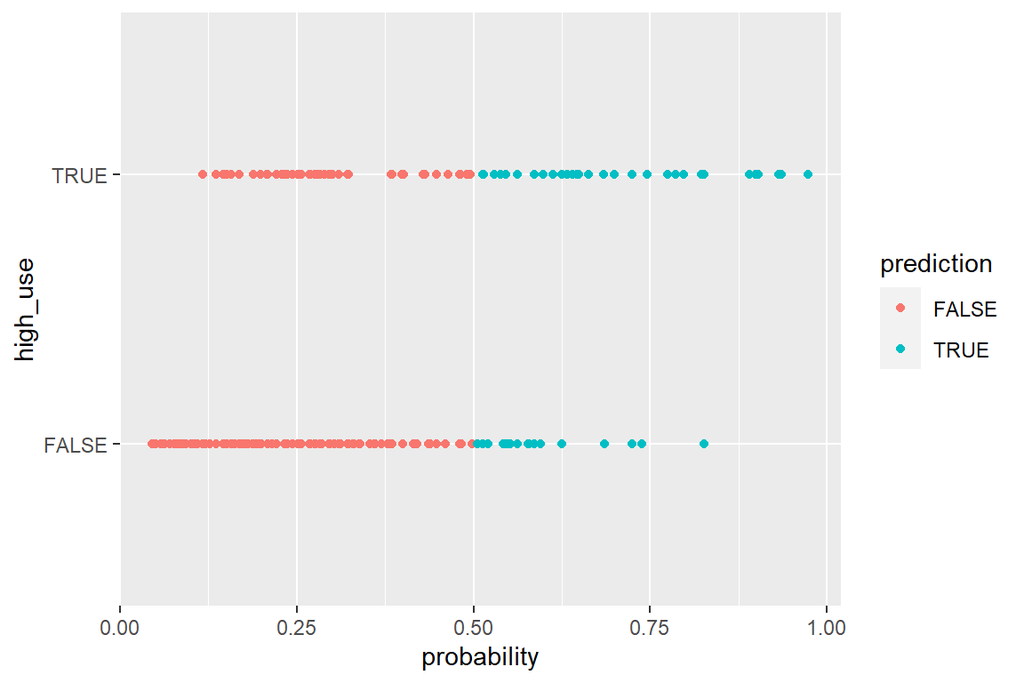

```r
# initialize a plot of 'high_use' versus 'probability' in 'alc'
g <- ggplot(data, aes(x = probability, y = high_use, col = prediction))

# define the geom as points and draw the plot
g + geom_point()
```

```r
# tabulate the target variable versus the predictions
table(high_use = data$high_use, prediction = data$prediction) %>% prop.table() %>% addmargins()
```

```
##         prediction
## high_use      FALSE       TRUE        Sum
##    FALSE 0.65706806 0.04973822 0.70680628
##    TRUE  0.20418848 0.08900524 0.29319372
##    Sum   0.86125654 0.13874346 1.00000000
```

```r
# define a loss function (mean prediction error)
loss_func <- function(class, prob) {
  n_wrong <- abs(class - prob) > 0.5
  mean(n_wrong)
}

# call loss_func to compute the average number of wrong predictions in the (training) data
loss_func(class = data$high_use, prob = data$probability)
```

```
## [1] 0.2539267
```

```r
# K-fold cross-validation
library(boot)
cv <- cv.glm(data = data, cost = loss_func, glmfit = m2, K = 10)

# average number of wrong predictions in the cross validation
cv$delta[1]
```

```
## [1] 0.2643979
```

# Clustering and Classification

## Data exploration

The **Boston** data set from MASS package will be used for this exercise. The data is stored on this [archive](http://lib.stat.cmu.edu/datasets/boston) and more information is available on this [link](https://stat.ethz.ch/R-manual/R-devel/library/MASS/html/Boston.html).

The data was originally used in this [paper](https://www.sciencedirect.com/science/article/pii/0095069678900062). It contains information about housing in Boston, Massachusetts collected by U.S. Census Service.

The data contains 506 rows and 14 variables. This data exploration will be focus more on the **crim** variable, which is the per capita per crime rate by town.

```r
#' Load the required packages
library(MASS)
```

```r
library(ggplot2)
library(GGally)

data("Boston")

#' Explore data structure
#' it has 506 observations and 14 attributes/variables
dim(Boston)
```

```
## [1] 506  14
```

```r
str(Boston)
```

```
## 'data.frame':    506 obs. of  14 variables:
##  $ crim   : num  0.00632 0.02731 0.02729 0.03237 0.06905 ...
##  $ zn     : num  18 0 0 0 0 0 12.5 12.5 12.5 12.5 ...
##  $ indus  : num  2.31 7.07 7.07 2.18 2.18 2.18 7.87 7.87 7.87 7.87 ...
##  $ chas   : int  0 0 0 0 0 0 0 0 0 0 ...
##  $ nox    : num  0.538 0.469 0.469 0.458 0.458 0.458 0.524 0.524 0.524 0.524 ...
##  $ rm     : num  6.58 6.42 7.18 7 7.15 ...
##  $ age    : num  65.2 78.9 61.1 45.8 54.2 58.7 66.6 96.1 100 85.9 ...
##  $ dis    : num  4.09 4.97 4.97 6.06 6.06 ...
##  $ rad    : int  1 2 2 3 3 3 5 5 5 5 ...
##  $ tax    : num  296 242 242 222 222 222 311 311 311 311 ...
##  $ ptratio: num  15.3 17.8 17.8 18.7 18.7 18.7 15.2 15.2 15.2 15.2 ...
##  $ black  : num  397 397 393 395 397 ...
##  $ lstat  : num  4.98 9.14 4.03 2.94 5.33 ...
##  $ medv   : num  24 21.6 34.7 33.4 36.2 28.7 22.9 27.1 16.5 18.9 ...
```

```r
#'check for nas
colSums(is.na(Boston))
```

```
##    crim      zn   indus    chas     nox      rm     age     dis     rad     tax
##       0       0       0       0       0       0       0       0       0       0
## ptratio   black   lstat    medv
##       0       0       0       0
```

```r
#' check summaries of each variables
summary(Boston)
```

```
##       crim                zn             indus            chas
##  Min.   : 0.00632   Min.   :  0.00   Min.   : 0.46   Min.   :0.00000
##  1st Qu.: 0.08205   1st Qu.:  0.00   1st Qu.: 5.19   1st Qu.:0.00000
##  Median : 0.25651   Median :  0.00   Median : 9.69   Median :0.00000
##  Mean   : 3.61352   Mean   : 11.36   Mean   :11.14   Mean   :0.06917
##  3rd Qu.: 3.67708   3rd Qu.: 12.50   3rd Qu.:18.10   3rd Qu.:0.00000
##  Max.   :88.97620   Max.   :100.00   Max.   :27.74   Max.   :1.00000
##       nox               rm             age              dis
##  Min.   :0.3850   Min.   :3.561   Min.   :  2.90   Min.   : 1.130
##  1st Qu.:0.4490   1st Qu.:5.886   1st Qu.: 45.02   1st Qu.: 2.100
##  Median :0.5380   Median :6.208   Median : 77.50   Median : 3.207
##  Mean   :0.5547   Mean   :6.285   Mean   : 68.57   Mean   : 3.795
##  3rd Qu.:0.6240   3rd Qu.:6.623   3rd Qu.: 94.08   3rd Qu.: 5.188
##  Max.   :0.8710   Max.   :8.780   Max.   :100.00   Max.   :12.127
##       rad              tax           ptratio          black
##  Min.   : 1.000   Min.   :187.0   Min.   :12.60   Min.   :  0.32
##  1st Qu.: 4.000   1st Qu.:279.0   1st Qu.:17.40   1st Qu.:375.38
##  Median : 5.000   Median :330.0   Median :19.05   Median :391.44
##  Mean   : 9.549   Mean   :408.2   Mean   :18.46   Mean   :356.67
##  3rd Qu.:24.000   3rd Qu.:666.0   3rd Qu.:20.20   3rd Qu.:396.23
##  Max.   :24.000   Max.   :711.0   Max.   :22.00   Max.   :396.90
##      lstat            medv
##  Min.   : 1.73   Min.   : 5.00
##  1st Qu.: 6.95   1st Qu.:17.02
##  Median :11.36   Median :21.20
##  Mean   :12.65   Mean   :22.53
##  3rd Qu.:16.95   3rd Qu.:25.00
##  Max.   :37.97   Max.   :50.00
```

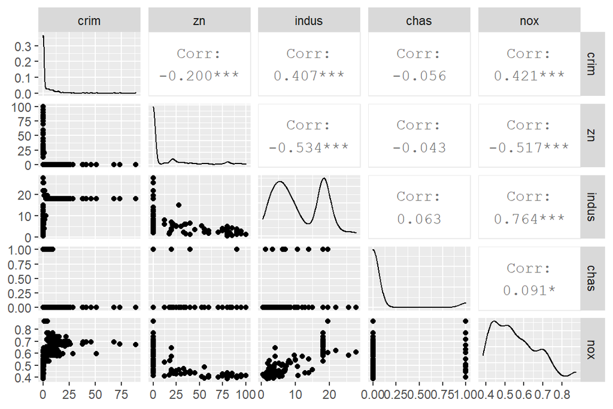

```r
ggpairs(Boston[1:5])
```

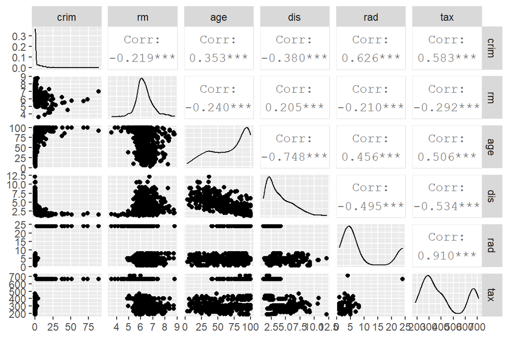

```r
ggpairs(Boston[c(1,6:10)])
```

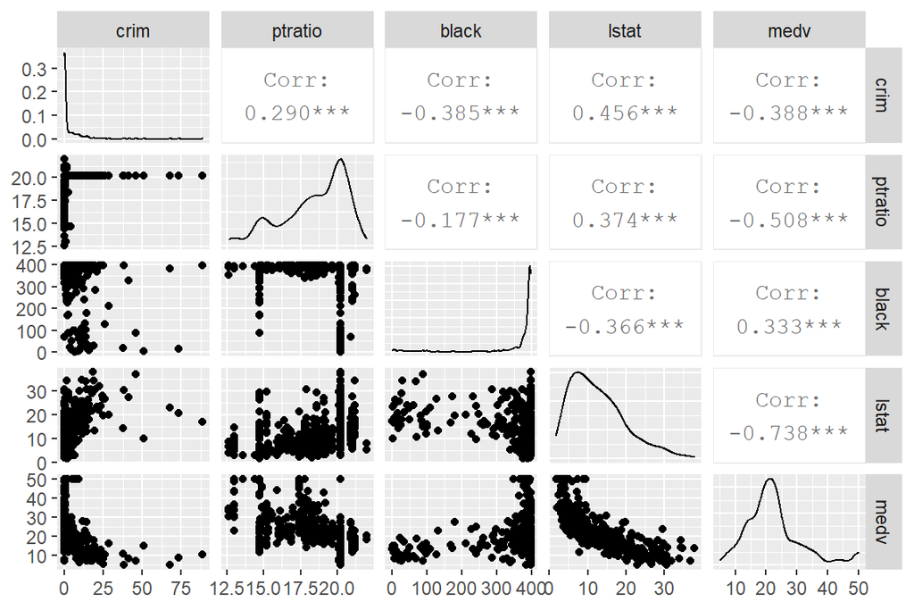

```r
ggpairs(Boston[c(1,11:14)])
```

The correlation of **crim** to other variables are not generally high and even the correlations higher than 0.5 does not look linear. The distribution also varies for each variable.

## Standardizing the data set

To proceed with the analysis, the variables were standardized (mean = 0). Scaling is done to prevents variables with large numbers from dominating the clustering of the observations.

```r
library(dplyr)
#' Scale the original data set
#' this is results to each attibute to have mean = 0
scaled.B<- scale(Boston) %>% as.data.frame()

#'
summary(scaled.B)
```

```
##       crim                 zn               indus              chas
##  Min.   :-0.419367   Min.   :-0.48724   Min.   :-1.5563   Min.   :-0.2723
##  1st Qu.:-0.410563   1st Qu.:-0.48724   1st Qu.:-0.8668   1st Qu.:-0.2723
##  Median :-0.390280   Median :-0.48724   Median :-0.2109   Median :-0.2723
##  Mean   : 0.000000   Mean   : 0.00000   Mean   : 0.0000   Mean   : 0.0000
##  3rd Qu.: 0.007389   3rd Qu.: 0.04872   3rd Qu.: 1.0150   3rd Qu.:-0.2723
##  Max.   : 9.924110   Max.   : 3.80047   Max.   : 2.4202   Max.   : 3.6648
##       nox                rm               age               dis
##  Min.   :-1.4644   Min.   :-3.8764   Min.   :-2.3331   Min.   :-1.2658
##  1st Qu.:-0.9121   1st Qu.:-0.5681   1st Qu.:-0.8366   1st Qu.:-0.8049
##  Median :-0.1441   Median :-0.1084   Median : 0.3171   Median :-0.2790
##  Mean   : 0.0000   Mean   : 0.0000   Mean   : 0.0000   Mean   : 0.0000
##  3rd Qu.: 0.5981   3rd Qu.: 0.4823   3rd Qu.: 0.9059   3rd Qu.: 0.6617
##  Max.   : 2.7296   Max.   : 3.5515   Max.   : 1.1164   Max.   : 3.9566
##       rad               tax             ptratio            black
##  Min.   :-0.9819   Min.   :-1.3127   Min.   :-2.7047   Min.   :-3.9033
##  1st Qu.:-0.6373   1st Qu.:-0.7668   1st Qu.:-0.4876   1st Qu.: 0.2049
##  Median :-0.5225   Median :-0.4642   Median : 0.2746   Median : 0.3808
##  Mean   : 0.0000   Mean   : 0.0000   Mean   : 0.0000   Mean   : 0.0000
##  3rd Qu.: 1.6596   3rd Qu.: 1.5294   3rd Qu.: 0.8058   3rd Qu.: 0.4332
##  Max.   : 1.6596   Max.   : 1.7964   Max.   : 1.6372   Max.   : 0.4406
##      lstat              medv
##  Min.   :-1.5296   Min.   :-1.9063
##  1st Qu.:-0.7986   1st Qu.:-0.5989
##  Median :-0.1811   Median :-0.1449
##  Mean   : 0.0000   Mean   : 0.0000
##  3rd Qu.: 0.6024   3rd Qu.: 0.2683
##  Max.   : 3.5453   Max.   : 2.9865
```

```r
#'
class(scaled.B)
```

```
## [1] "data.frame"
```

## Creating categorical variable **crime**

A new categorical variable **crime** will be created by classifiying **crim** values to either **“low”**, **“med_low”**, **“med_high”**, and **“high”**.

```r
#' print summary of variable 'crim'
summary(scaled.B$crim)
```

```
##      Min.   1st Qu.    Median      Mean   3rd Qu.      Max.
## -0.419367 -0.410563 -0.390280  0.000000  0.007389  9.924110
```

```r
#' create quantile vector of crim
bins<- quantile(scaled.B$crim)

#' create  categorical variable 'crime'
crime <- cut(scaled.B$crim, breaks = bins, include.lowest = TRUE, label = c("low", "med_low", "med_high", "high"))

# look at the table of the new factor crime
table(crime)
```

```
## crime
##      low  med_low med_high     high
##      127      126      126      127
```

```r
# remove original crim from the dataset
scaled.B <- dplyr::select(scaled.B, -crim) %>% data.frame(scaled.B, crime)

colnames(scaled.B)
```

```
##  [1] "zn"        "indus"     "chas"      "nox"       "rm"        "age"
##  [7] "dis"       "rad"       "tax"       "ptratio"   "black"     "lstat"
## [13] "medv"      "crim"      "zn.1"      "indus.1"   "chas.1"    "nox.1"
## [19] "rm.1"      "age.1"     "dis.1"     "rad.1"     "tax.1"     "ptratio.1"
## [25] "black.1"   "lstat.1"   "medv.1"    "crime"
```

```r
head(scaled.B, 5)
```

```
##           zn      indus       chas        nox        rm        age      dis
## 1  0.2845483 -1.2866362 -0.2723291 -0.1440749 0.4132629 -0.1198948 0.140075
## 2 -0.4872402 -0.5927944 -0.2723291 -0.7395304 0.1940824  0.3668034 0.556609
## 3 -0.4872402 -0.5927944 -0.2723291 -0.7395304 1.2814456 -0.2655490 0.556609
## 4 -0.4872402 -1.3055857 -0.2723291 -0.8344581 1.0152978 -0.8090878 1.076671
## 5 -0.4872402 -1.3055857 -0.2723291 -0.8344581 1.2273620 -0.5106743 1.076671
##          rad        tax    ptratio     black      lstat       medv       crim
## 1 -0.9818712 -0.6659492 -1.4575580 0.4406159 -1.0744990  0.1595278 -0.4193669
## 2 -0.8670245 -0.9863534 -0.3027945 0.4406159 -0.4919525 -0.1014239 -0.4169267
## 3 -0.8670245 -0.9863534 -0.3027945 0.3960351 -1.2075324  1.3229375 -0.4169290
## 4 -0.7521778 -1.1050216  0.1129203 0.4157514 -1.3601708  1.1815886 -0.4163384
## 5 -0.7521778 -1.1050216  0.1129203 0.4406159 -1.0254866  1.4860323 -0.4120741
##         zn.1    indus.1     chas.1      nox.1      rm.1      age.1    dis.1
## 1  0.2845483 -1.2866362 -0.2723291 -0.1440749 0.4132629 -0.1198948 0.140075
## 2 -0.4872402 -0.5927944 -0.2723291 -0.7395304 0.1940824  0.3668034 0.556609
## 3 -0.4872402 -0.5927944 -0.2723291 -0.7395304 1.2814456 -0.2655490 0.556609
## 4 -0.4872402 -1.3055857 -0.2723291 -0.8344581 1.0152978 -0.8090878 1.076671
## 5 -0.4872402 -1.3055857 -0.2723291 -0.8344581 1.2273620 -0.5106743 1.076671
##        rad.1      tax.1  ptratio.1   black.1    lstat.1     medv.1 crime
## 1 -0.9818712 -0.6659492 -1.4575580 0.4406159 -1.0744990  0.1595278   low
## 2 -0.8670245 -0.9863534 -0.3027945 0.4406159 -0.4919525 -0.1014239   low
## 3 -0.8670245 -0.9863534 -0.3027945 0.3960351 -1.2075324  1.3229375   low
## 4 -0.7521778 -1.1050216  0.1129203 0.4157514 -1.3601708  1.1815886   low
## 5 -0.7521778 -1.1050216  0.1129203 0.4406159 -1.0254866  1.4860323   low
```

## Creating **training** and **test** subset

Subset the data set into **training** and **test** set. The **training** set is composed of 80 % of the total observations while the **test** set will contain the rest of the observations.

```r
# number of rows in the Boston dataset
n <- nrow(scaled.B)

# choose randomly 80% of the rows
ind <- sample(n,  size = n * 0.8)

# create train set
train <- scaled.B[ind,]

#nrow(train) == n*.8

# create test set
test <- scaled.B[-ind,]

# save the correct classes from test data
correct_classes <- test$crime

# remove the crime variable from test data
test <- dplyr::select(test, -crime)
```

Contain observations from **crime** from the test to another file called **correct_classes**, then remove the **crime** variable from the test set.

## Fitting **linear discriminat analysis**

Perform **linear discriminant analysis** to the train set using **crime** as the response variable and the remaining variables as the covariates.

Then, proceed in creating a biplot to visualize the results.

```r
# linear discriminant analysis
lda.fit <- lda(crime ~ . , data = train)
# print the lda.fit object
lda.fit
```

```
## Call:
## lda(crime ~ ., data = train)
##
## Prior probabilities of groups:
##       low   med_low  med_high      high
## 0.2549505 0.2351485 0.2500000 0.2599010
##
## Group means:
##                   zn      indus        chas        nox          rm        age
## low       0.97474528 -0.8695641 -0.11943197 -0.8779589  0.41641342 -0.9051444
## med_low  -0.04583135 -0.3191242 -0.06511327 -0.6006452 -0.06460458 -0.4003960
## med_high -0.37601435  0.1194485  0.15646403  0.3626903  0.13286854  0.3975100
## high     -0.48724019  1.0170492 -0.08484810  1.0398501 -0.43359807  0.8216302
##                 dis        rad        tax     ptratio      black       lstat
## low       0.8520812 -0.6964270 -0.7136469 -0.45392277  0.3740398 -0.75063697
## med_low   0.3892186 -0.5502894 -0.5024993 -0.03683424  0.3464433 -0.20392222
## med_high -0.3860028 -0.3985409 -0.3175816 -0.35950368  0.0718337 -0.03093168
## high     -0.8500061  1.6388211  1.5145512  0.78158339 -0.8426159  0.92969819
##                 medv       crim        zn.1    indus.1      chas.1      nox.1
## low       0.48751199 -0.4148150  0.97474528 -0.8695641 -0.11943197 -0.8779589
## med_low   0.06453221 -0.4034420 -0.04583135 -0.3191242 -0.06511327 -0.6006452
## med_high  0.21034017 -0.2930291 -0.37601435  0.1194485  0.15646403  0.3626903
## high     -0.74614031  1.0974071 -0.48724019  1.0170492 -0.08484810  1.0398501
##                 rm.1      age.1      dis.1      rad.1      tax.1   ptratio.1
## low       0.41641342 -0.9051444  0.8520812 -0.6964270 -0.7136469 -0.45392277
## med_low  -0.06460458 -0.4003960  0.3892186 -0.5502894 -0.5024993 -0.03683424
## med_high  0.13286854  0.3975100 -0.3860028 -0.3985409 -0.3175816 -0.35950368
## high     -0.43359807  0.8216302 -0.8500061  1.6388211  1.5145512  0.78158339
##             black.1     lstat.1      medv.1
## low       0.3740398 -0.75063697  0.48751199
## med_low   0.3464433 -0.20392222  0.06453221
## med_high  0.0718337 -0.03093168  0.21034017
## high     -0.8426159  0.92969819 -0.74614031
##
## Coefficients of linear discriminants:
##                   LD1          LD2         LD3
## zn         0.04488259  0.333950136 -0.48607493
## indus     -0.00158610 -0.031444774  0.19572476
## chas      -0.03828634 -0.034799815  0.03615750
## nox        0.20097941 -0.385670015 -0.61899411
```

[output cut: 12 more lines]

```
## chas.1    -0.03828634 -0.034799815  0.03615750
## nox.1      0.20097941 -0.385670015 -0.61899411
## rm.1      -0.05719069 -0.008884109 -0.04581175
## age.1      0.12251042 -0.187626490 -0.06061456
## dis.1     -0.03095967 -0.103134757  0.16770557
## rad.1      1.50026253  0.427029977  0.01408896
## tax.1      0.05309758 -0.034617334  0.18523136
## ptratio.1  0.05714709  0.020956478 -0.05246835
## black.1   -0.05506002  0.026146539  0.06139093
## lstat.1    0.08260417 -0.111154094  0.24301712
## medv.1     0.10419666 -0.212173350 -0.02607792
##
## Proportion of trace:
##    LD1    LD2    LD3
## 0.9528 0.0364 0.0108
```

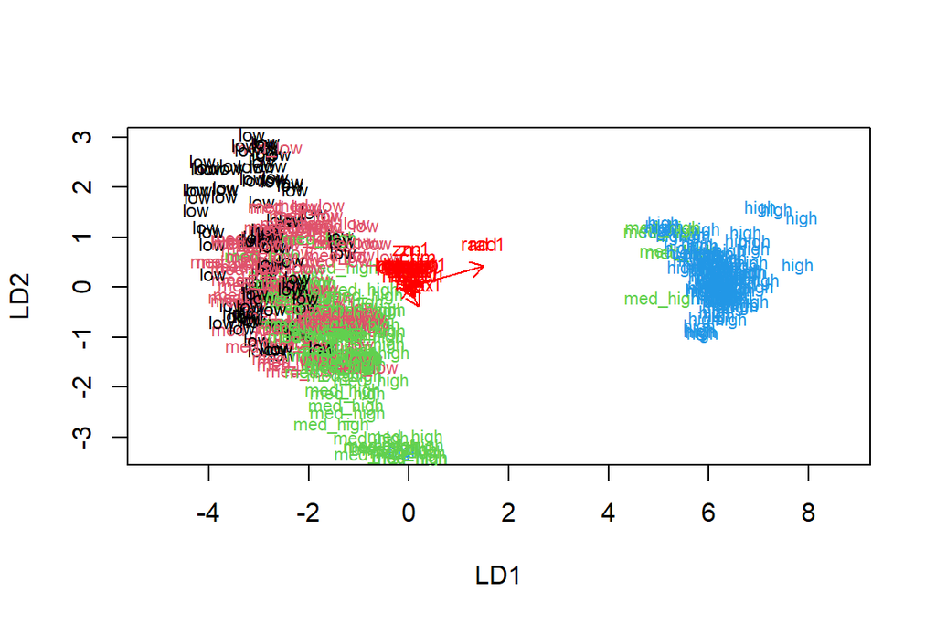

```r
# the function for lda biplot arrows
lda.arrows <- function(x, myscale = 1, arrow_heads = 0.1, color = "red", tex = 0.75, choices = c(1,2)){
  heads <- coef(x)
  arrows(x0 = 0, y0 = 0,
         x1 = myscale * heads[,choices[1]],
         y1 = myscale * heads[,choices[2]], col=color, length = arrow_heads)
  text(myscale * heads[,choices], labels = row.names(heads),
       cex = tex, col=color, pos=3)
}

# target classes as numeric
classes <- as.numeric(train$crime)

# plot the lda results
plot(lda.fit, dimen = 2, col = classes, pch = classes)
lda.arrows(lda.fit, myscale = 1)
```

## Predict the classes

We can create a new data set containing predicted value of **crime** based on the model created from the training set. We feed the test set to the model to predict **crime** values for each row. We can then compare the **correct_classes** we saved earlier and the predicted values from the model and see how correct prediction the model model made.

```r
# save the correct classes from test data
# correct_classes <- test$crime

# remove the crime variable from test data
# test <- dplyr::select(test, -crime)

# predict classes with test data
lda.pred <- predict(lda.fit, newdata = test)

# cross tabulate the results
table(correct = correct_classes, predicted = lda.pred$class)
```

```
##           predicted
## correct    low med_low med_high high
##   low       14      10        0    0
##   med_low    3      18       10    0
##   med_high   0       8       16    1
##   high       0       0        0   22
```

## Clustering

We can also used the model to creast clusters in the Boston data set and visualy inspect the clustering of each variable based on **crime**.

```r
Boston.std<- scale(Boston) %>% as.data.frame()

# euclidean distance matrix
dist_eu <- dist(Boston.std)

# look at the summary of the distances
summary(dist_eu)
```

```
##    Min. 1st Qu.  Median    Mean 3rd Qu.    Max.
##  0.1343  3.4625  4.8241  4.9111  6.1863 14.3970
```

```r
# manhattan distance matrix
dist_man <- dist(Boston, method = "manhattan")

# look at the summary of the distances
summary(dist_man)
```

```
##     Min.  1st Qu.   Median     Mean  3rd Qu.     Max.
##    2.016  149.145  279.505  342.899  509.707 1198.265
```

[figure not shown]

```r
# k-means clustering
km <-kmeans(Boston.std, centers = 3)

# plot the Boston dataset with clusters
pairs(Boston.std, col = km$cluster)
```

```r
#ggpairs(Boston.std[1:5], col = km$cluster)
#ggpairs(Boston.std[6:10], col = km$cluster)
#ggpairs(Boston.std[11:14], col = km$cluster)
```

# Dimensionality Reduction

## Data exploration

The data for this exercise can be accessed via this [link](http://s3.amazonaws.com/assets.datacamp.com/production/course_2218/datasets/human1.txt). This data is from United Nations Development Programme and you can read more about the data on this [page](http://hdr.undp.org/en/content/human-development-index-hdi).

However, the original data set has been modified for this analysis and can be accessed using this [link](http://s3.amazonaws.com/assets.datacamp.com/production/course_2218/datasets/human2.txt).

The **human2.txt** has 8 columns and 155 rows and country names are assigned as the **row.names**.

```r
#' access and explore the data
url <- "http://s3.amazonaws.com/assets.datacamp.com/production/course_2218/datasets/human2.txt"

human<-read.csv(url, header = TRUE, sep = ',')

dim(human)
```

```
## [1] 155   8
```

```r
str(human)
```

```
## 'data.frame':    155 obs. of  8 variables:
##  $ Edu2.FM  : num  1.007 0.997 0.983 0.989 0.969 ...
##  $ Labo.FM  : num  0.891 0.819 0.825 0.884 0.829 ...
##  $ Edu.Exp  : num  17.5 20.2 15.8 18.7 17.9 16.5 18.6 16.5 15.9 19.2 ...
##  $ Life.Exp : num  81.6 82.4 83 80.2 81.6 80.9 80.9 79.1 82 81.8 ...
##  $ GNI      : int  64992 42261 56431 44025 45435 43919 39568 52947 42155 32689 ...
##  $ Mat.Mor  : int  4 6 6 5 6 7 9 28 11 8 ...
##  $ Ado.Birth: num  7.8 12.1 1.9 5.1 6.2 3.8 8.2 31 14.5 25.3 ...
##  $ Parli.F  : num  39.6 30.5 28.5 38 36.9 36.9 19.9 19.4 28.2 31.4 ...
```

```r
colnames(human)
```

```
## [1] "Edu2.FM"   "Labo.FM"   "Edu.Exp"   "Life.Exp"  "GNI"       "Mat.Mor"
## [7] "Ado.Birth" "Parli.F"
```